# Graphs - Bonus Assignment

ANLT 212 - Analytics Computing

Copyright © Dana Nehoran 2017

**Class 08 - Class Assignment**

**Jenish Vinodbhai Dhaduk**

**Student ID- 989354198**

Project Title - Bonus Assignment(Graphs)

# Editorial Reports Company

The Editorial Reports Company is conducting a research to examine article republishing and reference among various publications.

As part of this research, articles are being analyzed for their flow through the print and online media. For example, newspapers often refer to each other's articles, so an article published by the New York Times may be referred to in the Los Angeles Times soon after.

Create a network with the following characteristics:

- 12 newspapers
- At least 65 references between newspapers
- At least 12 self-references
- 15 reporters (reporters may work for multiple newspapers)

> **Question 1:** Adjacent Matrix

**a)** Create the adjacent matrix for Editorial Reports

a.I) Create the adjacency matrix with the newspapers you have selected and the references between them  
a.II) Print the number of references you have  
a.III) Plot your graph

Hint: One vertix for each newspaper. One edge for each reference.

Your answer here

|  | USA TODAY | WALL STREET JOURNAL | NEWYORK TIMES | SF CHRONICAL | NEWYORK POST | LA TIMES | WASHINGTON POST | STAR TRIBUNE | NEWSDAY | CHICAGO TRIBUNE | BOSTON GLOBE | THE TIMES |
| --- | --- | --- | --- | --- | --- | --- | --- | --- | --- | --- | --- | --- |
| USA TODAY | 1 | 1 | 0 | 1 | 1 | 0 | 0 | 0 | 0 | 1 | 0 | 1 |
| WALL STREET JOURNAL | 1 | 1 | 1 | 0 | 0 | 0 | 0 | 0 | 1 | 0 | 0 | 1 |
| NEWYORK TIMES | 0 | 1 | 1 | 1 | 0 | 0 | 1 | 0 | 0 | 0 | 0 | 1 |
| SF CHRONICAL | 1 | 1 | 1 | 1 | 1 | 0 | 0 | 0 | 1 | 1 | 0 | 0 |
| NEWYORK POST | 0 | 0 | 0 | 1 | 1 | 1 | 0 | 0 | 0 | 1 | 0 | 1 |
| LA TIMES | 1 | 0 | 1 | 0 | 1 | 0 | 0 | 1 | 0 | 1 | 0 | 1 |
| WASHINGTON POST | 0 | 0 | 0 | 1 | 0 | 1 | 1 | 0 | 0 | 0 | 1 | 0 |
| STAR TRIBUNE | 0 | 0 | 0 | 0 | 0 | 0 | 1 | 1 | 0 | 1 | 0 | 1 |
| NEWSDAY | 1 | 1 | 0 | 1 | 0 | 1 | 0 | 1 | 1 | 0 | 0 | 1 |
| CHICAGO TRIBUNE | 0 | 0 | 0 | 0 | 0 | 1 | 1 | 0 | 0 | 1 | 1 | 0 |
| BOSTON GLOBE | 1 | 1 | 1 | 0 | 0 | 1 | 1 | 1 | 0 | 0 | 1 | 0 |
| THE TIMES | 0 | 0 | 0 | 1 | 0 | 1 | 1 | 1 | 0 | 1 | 0 | 1 |

```
The number of references between newspapers is: 66
```

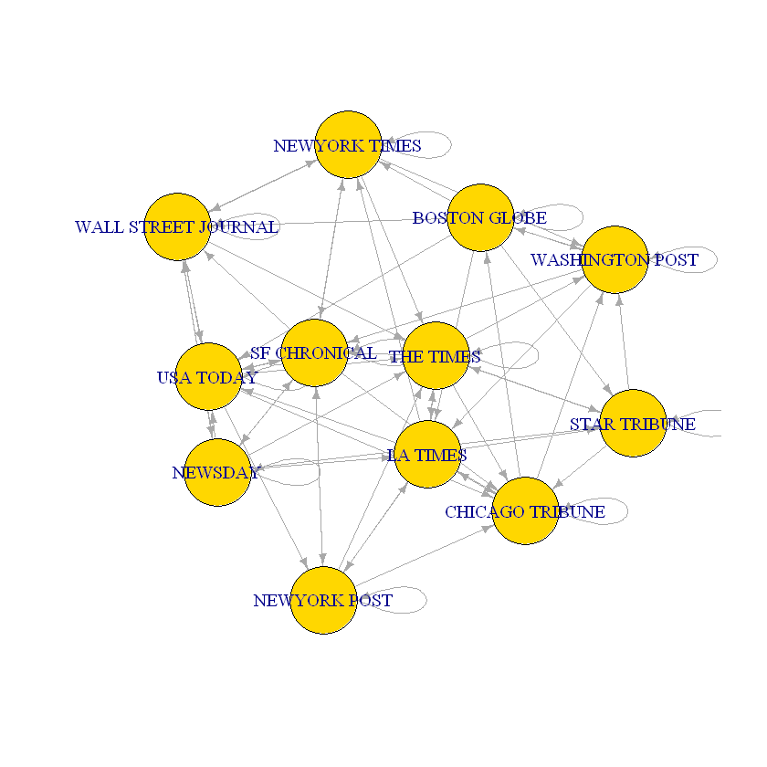

```r
rm(list=ls()) # clear memory
library(igraph) # load package igraph

# Adjacency matrices: graph.adjacency() and get.adjacency()
Amat<-matrix(
c(1, 1, 0, 1, 1, 0, 0, 0, 0, 1, 0, 1,
  1, 1, 1, 0, 0, 0, 0, 0, 1, 0, 0, 1,
  0, 1, 1, 1, 0, 0, 1, 0, 0, 0, 0, 1,
  1, 1, 1, 1, 1, 0, 0, 0, 1, 1, 0, 0,
  0, 0, 0, 1, 1, 1, 0, 0, 0, 1, 0, 1,
  1, 0, 1, 0, 1, 0, 0, 1, 0, 1, 0, 1,
  0, 0, 0, 1, 0, 1, 1, 0, 0, 0, 1, 0,
  0, 0, 0, 0, 0, 0, 1, 1, 0, 1, 0, 1,
  1, 1, 0, 1, 0, 1, 0, 1, 1, 0, 0, 1,
  0, 0, 0, 0, 0, 1, 1, 0, 0, 1, 1, 0,
  1, 1, 1, 0, 0, 1, 1, 1, 0, 0, 1, 0,
  0, 0, 0, 1, 0, 1, 1, 1, 0, 1, 0, 1), # data elements
nrow=12, # number of rows
ncol=12, # number of columns
byrow = TRUE) # fill matrix by rows

dist_centers <- c("USA TODAY","WALL STREET JOURNAL","NEWYORK TIMES","SF CHRONICAL","NEWYORK POST",
                  "LA TIMES","WASHINGTON POST","STAR TRIBUNE","NEWSDAY","CHICAGO TRIBUNE","BOSTON GLOBE","THE TIMES")

rownames(Amat) <- dist_centers
colnames(Amat) <- dist_centers

Amat
cat("The number of references between newspapers is:", sum(Amat))

news_g <- graph.adjacency(Amat, mode="directed")
plot(news_g, edge.arrow.size=.5, vertex.color="gold", vertex.size=30)
```

The above graph shows the number of refrerred articles among different Newspapers.

> **Question 2:** Editorial Report Matrix

**a)** Apply changes to the Editorial Reports matrix: Newspaper going out of business.

a.I) The newspaper you've listed 7th has declared bankruptcy. Delete that newspaper from your matrix **without redefining the matrix**  
a.II) Print the new number of references you have  
a.III) Plot your new graph

Your answer here

|  | USA TODAY | WALL STREET JOURNAL | NEWYORK TIMES | SF CHRONICAL | NEWYORK POST | LA TIMES | STAR TRIBUNE | NEWSDAY | CHICAGO TRIBUNE | BOSTON GLOBE | THE TIMES |
| --- | --- | --- | --- | --- | --- | --- | --- | --- | --- | --- | --- |
| USA TODAY | 1 | 1 | 0 | 1 | 1 | 0 | 0 | 0 | 1 | 0 | 1 |
| WALL STREET JOURNAL | 1 | 1 | 1 | 0 | 0 | 0 | 0 | 1 | 0 | 0 | 1 |
| NEWYORK TIMES | 0 | 1 | 1 | 1 | 0 | 0 | 0 | 0 | 0 | 0 | 1 |
| SF CHRONICAL | 1 | 1 | 1 | 1 | 1 | 0 | 0 | 1 | 1 | 0 | 0 |
| NEWYORK POST | 0 | 0 | 0 | 1 | 1 | 1 | 0 | 0 | 1 | 0 | 1 |
| LA TIMES | 1 | 0 | 1 | 0 | 1 | 0 | 1 | 0 | 1 | 0 | 1 |
| STAR TRIBUNE | 0 | 0 | 0 | 0 | 0 | 0 | 1 | 0 | 1 | 0 | 1 |
| NEWSDAY | 1 | 1 | 0 | 1 | 0 | 1 | 1 | 1 | 0 | 0 | 1 |
| CHICAGO TRIBUNE | 0 | 0 | 0 | 0 | 0 | 1 | 0 | 0 | 1 | 1 | 0 |
| BOSTON GLOBE | 1 | 1 | 1 | 0 | 0 | 1 | 1 | 0 | 0 | 1 | 0 |
| THE TIMES | 0 | 0 | 0 | 1 | 0 | 1 | 1 | 0 | 1 | 0 | 1 |

```
The number of references between newspapers is: 57
```

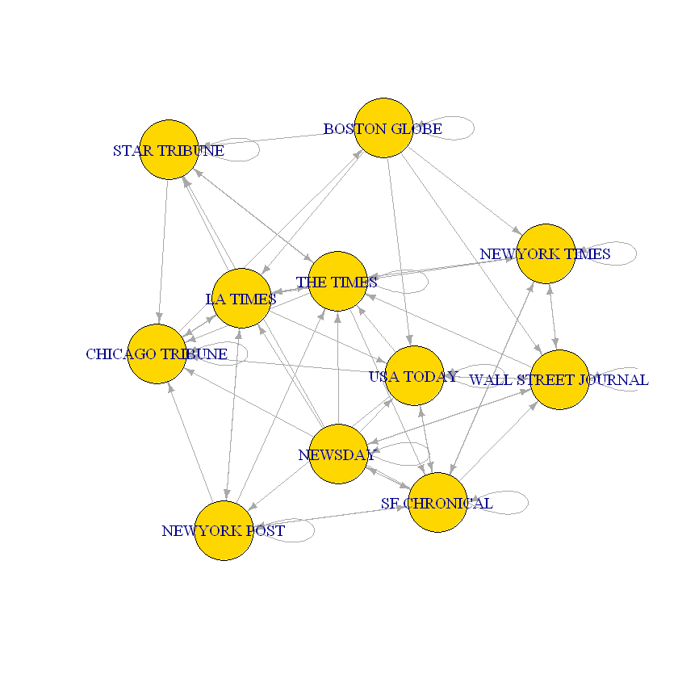

```r
Amat<-Amat[,-7]
Amat<-Amat[-7,]

dist_centers <- c("USA TODAY","WALL STREET JOURNAL","NEWYORK TIMES","SF CHRONICAL","NEWYORK POST",
                  "LA TIMES","STAR TRIBUNE","NEWSDAY","CHICAGO TRIBUNE","BOSTON GLOBE","THE TIMES")

rownames(Amat) <- dist_centers
colnames(Amat) <- dist_centers

Amat
cat("The number of references between newspapers is:", sum(Amat))

news_g <- graph.adjacency(Amat, mode="directed")
plot(news_g, edge.arrow.size=.5, vertex.color="gold", vertex.size=30)
```

The above graph shows that **Washington post** has declared bankruptcy and is thus **deleted** from the graph.

> **Question 3:** Newspaper Merger

**a)** Apply changes to the Editorial Reports matrix: Newspaper merger.

a.I) The newspaper you've listed 2nd has acquired the one you've listed 4th. Merge the 4th newspaper (including all its articles) into the 2nd, and remove the 4th newspaper entirely from the matrix **without redefining the matrix**  
a.II) Print the up-to-date number of references, and verify the merger hasn't changed it  
a.III) Plot your new graph

|  | USA TODAY | WALL STREET JOURNAL | NEWYORK TIMES | NEWYORK POST | LA TIMES | STAR TRIBUNE | NEWSDAY | CHICAGO TRIBUNE | BOSTON GLOBE | THE TIMES |
| --- | --- | --- | --- | --- | --- | --- | --- | --- | --- | --- |
| USA TODAY | 1 | 1 | 0 | 1 | 0 | 0 | 0 | 1 | 0 | 1 |
| WALL STREET JOURNAL | 2 | 2 | 2 | 1 | 0 | 0 | 2 | 1 | 0 | 1 |
| NEWYORK TIMES | 0 | 1 | 1 | 0 | 0 | 0 | 0 | 0 | 0 | 1 |
| NEWYORK POST | 0 | 0 | 0 | 1 | 1 | 0 | 0 | 1 | 0 | 1 |
| LA TIMES | 1 | 0 | 1 | 1 | 0 | 1 | 0 | 1 | 0 | 1 |
| STAR TRIBUNE | 0 | 0 | 0 | 0 | 0 | 1 | 0 | 1 | 0 | 1 |
| NEWSDAY | 1 | 1 | 0 | 0 | 1 | 1 | 1 | 0 | 0 | 1 |
| CHICAGO TRIBUNE | 0 | 0 | 0 | 0 | 1 | 0 | 0 | 1 | 1 | 0 |
| BOSTON GLOBE | 1 | 1 | 1 | 0 | 1 | 1 | 0 | 0 | 1 | 0 |
| THE TIMES | 0 | 0 | 0 | 0 | 1 | 1 | 0 | 1 | 0 | 1 |

```
The number of references between newspapers is: 51
```

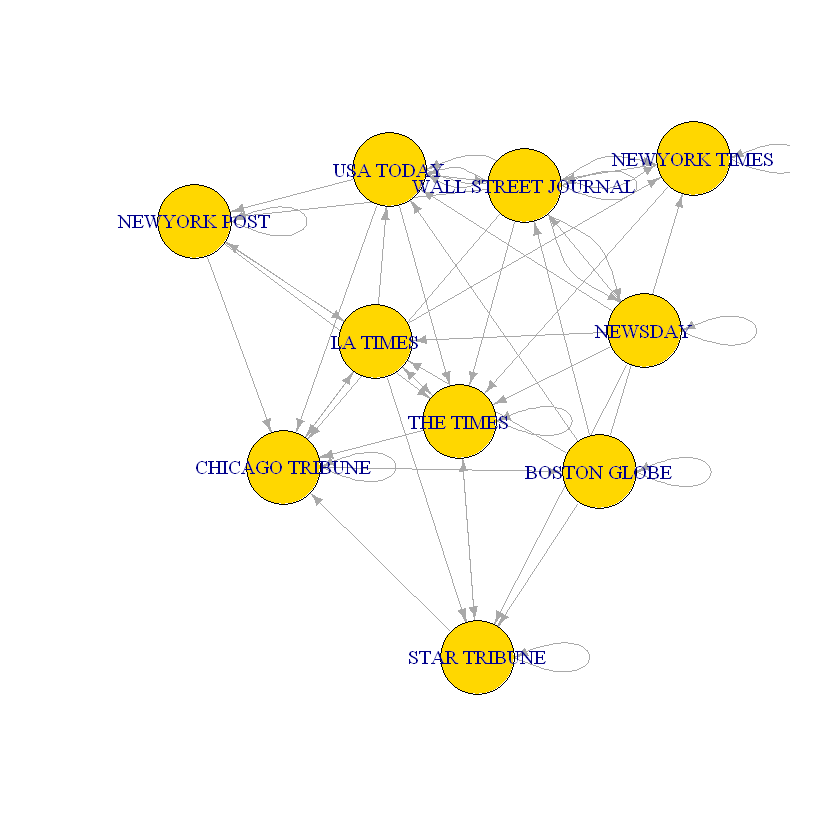

```r
Amat[2,]<-Amat[4,] +Amat[2,]
Amat<-Amat[,-4]
Amat<-Amat[-4,]
dist_centers <- c("USA TODAY","WALL STREET JOURNAL","NEWYORK TIMES","NEWYORK POST",
                  "LA TIMES","STAR TRIBUNE","NEWSDAY","CHICAGO TRIBUNE","BOSTON GLOBE","THE TIMES")

rownames(Amat) <- dist_centers
colnames(Amat) <- dist_centers

Amat
cat("The number of references between newspapers is:", sum(Amat))

news_g <- graph.adjacency(Amat, mode="directed")
plot(news_g, edge.arrow.size=.5, vertex.color="gold", vertex.size=30)
```

> **Question 4:** Adding Properties

**a)** Add properties to each link that contain the name of the reporter who wrote the article, the article's genre, and at least one more property of your choice.

Your answer here

```r
V(news_g)
```

```
+ 10/10 vertices, named, from 9c114be:
 [1] USA TODAY           WALL STREET JOURNAL NEWYORK TIMES
 [4] NEWYORK POST        LA TIMES            STAR TRIBUNE
 [7] NEWSDAY             CHICAGO TRIBUNE     BOSTON GLOBE
[10] THE TIMES
```

```r
E(news_g)
```

```
+ 51/51 edges from 9c114be (vertex names):
 [1] USA TODAY          ->USA TODAY
 [2] USA TODAY          ->WALL STREET JOURNAL
 [3] USA TODAY          ->NEWYORK POST
 [4] USA TODAY          ->CHICAGO TRIBUNE
 [5] USA TODAY          ->THE TIMES
 [6] WALL STREET JOURNAL->USA TODAY
 [7] WALL STREET JOURNAL->USA TODAY
 [8] WALL STREET JOURNAL->WALL STREET JOURNAL
 [9] WALL STREET JOURNAL->WALL STREET JOURNAL
[10] WALL STREET JOURNAL->NEWYORK TIMES
+ ... omitted several edges
```

```r
E(news_g)$reporter <- c("John", "Taylor", "Chris", "Lilly", "Larry", "Henderson", "Rohan", "Barbara", "Kallie", "Pegi",
                        "Mark", "Steve", "Derin", "Wendy", "Harry", "Larry", "Barbara", "Wendy", "Rohan", "Kallie",
                        "Taylor", "Chris", "Wendy", "Rohan", "John", "Larry", "Lilly", "Larry", "Henderson", "Pegi",
                        "Mark", "Steve", "Chris", "Lilly", "Larry", "Henderson", "Wendy", "Kallie", "Pegi", "Pegi",
                        "John", "Henderson", "Derin", "Wendy", "Harry",  "Steve", "Derin", "Wendy", "Rohan", "John",
                        "Wendy"
                        )
E(news_g)$genre <- c("Sports", "Technology", "Science", "Computer", "Retail", "Bussiness", "Stock Exchnage", "Hollywood", "Science", "Computer",
                        "Science", "Technology", "Science", "Computer", "Sports", "Technology", "Science", "Computer", "Stock Exchnage", "Hollywood",
                        "Retail", "Bussiness", "Stock Exchnage", "Hollywood", "Science", "Computer", "Retail", "Bussiness", "Stock Exchnage", "Hollywood",
                        "Hollywood", "Science", "Computer", "Retail", "Retail", "Bussiness", "Stock Exchnage", "Retail", "Bussiness", "Stock Exchnage",
                        "Hollywood", "Science", "Computer","Bussiness", "Science", "Bussiness", "Sports", "Sports", "Hollywood","Computer",
                        "Science"
                        )
E(news_g)$length <- c(300, 500, 600, 300, 300, 300, 500, 600, 800, 1000,
                        300, 300, 350, 400, 480, 600, 300, 300, 400, 690,
                        690, 300, 600, 400, 900, 1000, 300, 300, 400, 900,
                        600, 600, 350, 400, 480, 600, 300, 900, 400, 900,
                        300, 900, 350, 400, 480, 1000, 690, 300, 400, 400,
                        1000
                        )
edge_attr(news_g)
E(news_g)[[]]
```

**$reporter**

1. 'John'

2. 'Taylor'

3. 'Chris'

4. 'Lilly'

5. 'Larry'

6. 'Henderson'

7. 'Rohan'

8. 'Barbara'

9. 'Kallie'

10. 'Pegi'

11. 'Mark'

12. 'Steve'

13. 'Derin'

14. 'Wendy'

15. 'Harry'

16. 'Larry'

17. 'Barbara'

18. 'Wendy'

19. 'Rohan'

20. 'Kallie'

21. 'Taylor'

22. 'Chris'

23. 'Wendy'

24. 'Rohan'

25. 'John'

26. 'Larry'

27. 'Lilly'

28. 'Larry'

29. 'Henderson'

30. 'Pegi'

31. 'Mark'

32. 'Steve'

33. 'Chris'

34. 'Lilly'

35. 'Larry'

36. 'Henderson'

37. 'Wendy'

38. 'Kallie'

39. 'Pegi'

40. 'Pegi'

41. 'John'

42. 'Henderson'

43. 'Derin'

44. 'Wendy'

45. 'Harry'

46. 'Steve'

47. 'Derin'

48. 'Wendy'

49. 'Rohan'

50. 'John'

51. 'Wendy'

**$genre**

1. 'Sports'

2. 'Technology'

3. 'Science'

4. 'Computer'

5. 'Retail'

6. 'Bussiness'

7. 'Stock Exchnage'

8. 'Hollywood'

9. 'Science'

10. 'Computer'

11. 'Science'

12. 'Technology'

13. 'Science'

14. 'Computer'

15. 'Sports'

16. 'Technology'

17. 'Science'

18. 'Computer'

19. 'Stock Exchnage'

20. 'Hollywood'

21. 'Retail'

22. 'Bussiness'

23. 'Stock Exchnage'

24. 'Hollywood'

25. 'Science'

26. 'Computer'

27. 'Retail'

28. 'Bussiness'

29. 'Stock Exchnage'

30. 'Hollywood'

31. 'Hollywood'

32. 'Science'

33. 'Computer'

34. 'Retail'

35. 'Retail'

36. 'Bussiness'

37. 'Stock Exchnage'

38. 'Retail'

39. 'Bussiness'

40. 'Stock Exchnage'

41. 'Hollywood'

42. 'Science'

43. 'Computer'

44. 'Bussiness'

45. 'Science'

46. 'Bussiness'

47. 'Sports'

48. 'Sports'

49. 'Hollywood'

50. 'Computer'

51. 'Science'

**$length**

1. 300

2. 500

3. 600

4. 300

5. 300

6. 300

7. 500

8. 600

9. 800

10. 1000

11. 300

12. 300

13. 350

14. 400

15. 480

16. 600

17. 300

18. 300

19. 400

20. 690

21. 690

22. 300

23. 600

24. 400

25. 900

26. 1000

27. 300

28. 300

29. 400

30. 900

31. 600

32. 600

33. 350

34. 400

35. 480

36. 600

37. 300

38. 900

39. 400

40. 900

41. 300

42. 900

43. 350

44. 400

45. 480

46. 1000

47. 690

48. 300

49. 400

50. 400

51. 1000

```
+ 51/51 edges from 9c114be (vertex names):
                  tail                head tid hid  reporter          genre
1            USA TODAY           USA TODAY   1   1      John         Sports
2            USA TODAY WALL STREET JOURNAL   1   2    Taylor     Technology
3            USA TODAY        NEWYORK POST   1   4     Chris        Science
4            USA TODAY     CHICAGO TRIBUNE   1   8     Lilly       Computer
5            USA TODAY           THE TIMES   1  10     Larry         Retail
6  WALL STREET JOURNAL           USA TODAY   2   1 Henderson      Bussiness
7  WALL STREET JOURNAL           USA TODAY   2   1     Rohan Stock Exchnage
8  WALL STREET JOURNAL WALL STREET JOURNAL   2   2   Barbara      Hollywood
9  WALL STREET JOURNAL WALL STREET JOURNAL   2   2    Kallie        Science
10 WALL STREET JOURNAL       NEWYORK TIMES   2   3      Pegi       Computer
11 WALL STREET JOURNAL       NEWYORK TIMES   2   3      Mark        Science
12 WALL STREET JOURNAL        NEWYORK POST   2   4     Steve     Technology
13 WALL STREET JOURNAL             NEWSDAY   2   7     Derin        Science
```

[output cut: 90 more lines]

The new properties are added to the refrences of the articles.

> **Question 5:** Referring Articles

**a)** Select 2 newspapers of your choice. What are all the articles that were published by the first newspaper and referred to by the other?

Your answer here

```r
my.ref <- E(news_g)["USA TODAY" %‐>% "WALL STREET JOURNAL"]
refered <- data.frame(reporter = my.ref$reporter, genre = my.ref$genre, length = my.ref$length)
refered
```

| reporter | genre | length |
| --- | --- | --- |
| Taylor | Technology | 500 |

There is one article on technology which was pubished on **USA TODAY** and was reffered to **WALL STREET JOURNAL**.

> **Question 6:** Reporters

**a)** What reporter is the one referred to the most?

Your answer here

```r
max(E(news_g)$reporter)
```

'Wendy'

**Wendy** is referred the most among all the reporters.

> **Question 7:** Your Own Question

**a)** Creative points. Use your imagination. Ask a question and answer it with a result and a plot.

Your answer here

Which genre is most reffered among all the genres?

```r
max(E(news_g)$genre)
```